# Practica 2

Murillo Alba Josué Iván

Febrero 2025

```r
library(dplyr)
```

```r
n <- 1e6
w <- rnorm(n)
x <- numeric(n)
x1 <- numeric(n)
x2 <- numeric(n)

for (t in 2:n)
  x[t] <- -(1/3)*w[t-1] + w[t]

#plot(x, type = 'l')


# Covarianza
g0 <- cov(x,x)

for(t in 2:n)
  x1[t] <- x[t-1]

cov(x,x1)
```

```
## [1] -0.335738
```

```r
#head(x)
#head(x1)


for(t in 3:n)
  x2[t] <- x[t-2]

cov(x,x2)
```

```
## [1] 0.0006035611
```

Sea {Wt} un proceso de ruido blanco i.i.d. N(0, 1). Varianza σ2 = 1. Considera los siguientes procesos estocásticos.

1. Determina si los procesos son MA, AR o ARMA y de qué orden.
2. Determina si los procesos estocásticos son estacionarios o no.
3. Realiza una grá ca con los primeros 1000 valores, para cada uno de los procesos.
4. Para cada proceso de los incisos a) b) y c):
1. Calcula algebraicamente el valor esperado, µ.
2. Calcula el estimador de la media, µˆ, usando R.
3. Calcula algebraicamente:
1. γ0 = Cov(Xt , Xt)
2. γ1 = Cov(Xt , Xt−1)
3. γ2 = Cov(Xt , Xt−2)
4. γ3 = Cov(Xt , Xt−3)
4. Calcula los siguientes estimadores, usando R.
1. γˆ0
2. γˆ1
3. γˆ2
4. γˆ3

# A

1. Xt = 3Wt−3 + Wt

## 1

El proceso estocastico es de MA (3)

## 2

Es un proceso de MA por lo que sus caracteristicas probabilisticas son constantes a lo largo del tiempo Estacionario

## 3

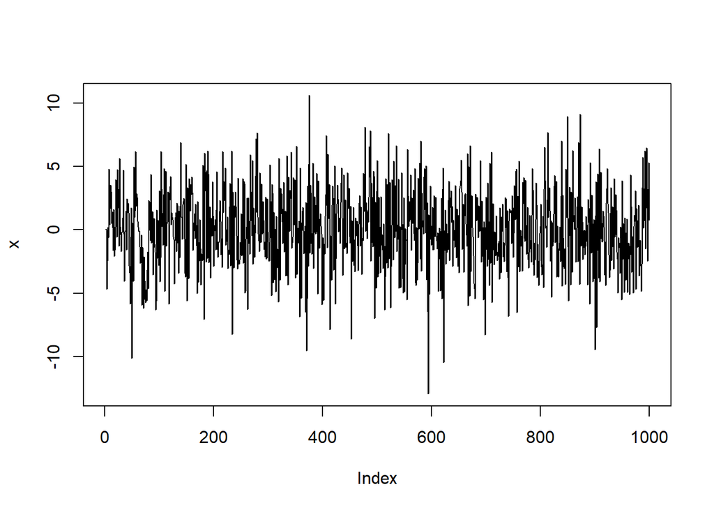

```r
n <- 1000
w <- rnorm(n)
x <- numeric(n)


for (t in 4:n)
  x[t] <- 3*w[t-3] + w[t]

plot(x, type = 'l')
```

## 4

ii

```r
n <- 1000
w <- rnorm(n)
x <- numeric(n)


for (t in 4:n)
  x[t] <- 3*w[t-3] + w[t]

mean(x)
```

```
## [1] -0.07895902
```

iv

```r
n <- 1e6
w <- rnorm(n)
x <- numeric(n)
x1 <- numeric(n)
x2 <- numeric(n)
x3 <- numeric(n)

for (t in 4:n)
  x[t] <- 3*w[t-3] + w[t]

for(t in 4:n)
  x1[t] <- x[t]
cov(x,x)
```

```
## [1] 9.981684
```

```r
for(t in 4:n)
  x1[t] <- x[t-1]

cov(x,x1)
```

```
## [1] 0.003067802
```

```r
for(t in 4:n)
  x2[t] <- x[t-2]

cov(x,x2)
```

```
## [1] -0.01233177
```

```r
for(t in 4:n)
  x3[t] <- x[t-3]

cov(x,x3)
```

```
## [1] 2.999164
```

# B

1. 2. Xt =−1/2 Wt−1 + Wt

## 1

El proceso estocastico es de MA (1)

## 2

Es un proceso de MA por lo que sus caracteristicas probabilisticas son constantes a lo largo del tiempo Estacionario

## 3

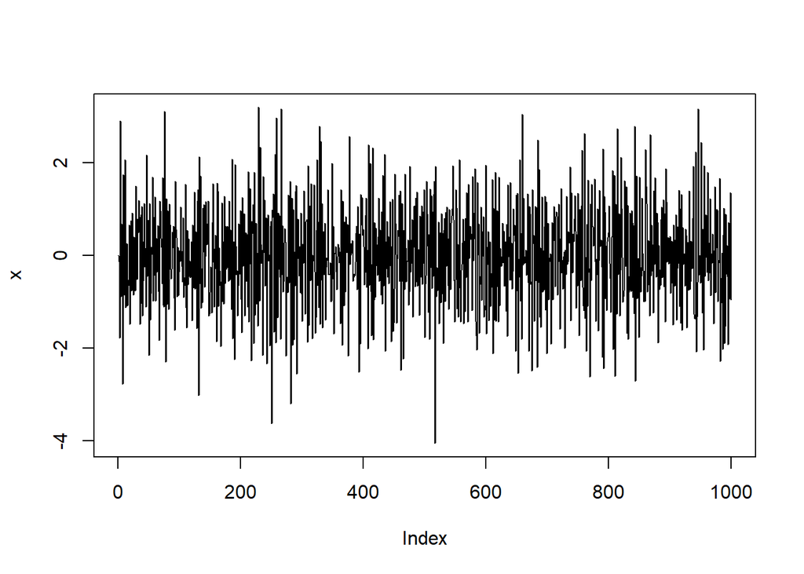

```r
n <- 1000
w <- rnorm(n)
x <- numeric(n)


for (t in 2:n)
  x[t] <- -(1/2)*w[t-1] + w[t]

plot(x, type = 'l')
```

## 4

ii

```r
n <- 1000
w <- rnorm(n)
x <- numeric(n)


for (t in 2:n)
  x[t] <- -(1/2)*w[t-1] + w[t]

mean(x)
```

```
## [1] 0.005788922
```

iv

```r
n <- 1e6
w <- rnorm(n)
x <- numeric(n)
x1 <- numeric(n)
x2 <- numeric(n)
x3 <- numeric(n)

for (t in 2:n)
  x[t] <- -(1/2)*w[t-1] + w[t]

for(t in 2:n)
  x1[t] <- x[t]
cov(x,x)
```

```
## [1] 1.252536
```

```r
for(t in 2:n)
  x1[t] <- x[t-1]

cov(x,x1)
```

```
## [1] -0.5011735
```

```r
for(t in 3:n)
  x2[t] <- x[t-2]

cov(x,x2)
```

```
## [1] -0.0002737068
```

```r
for(t in 4:n)
  x3[t] <- x[t-3]

cov(x,x3)
```

```
## [1] 0.001308784
```

# c

3. Xt = 3Wt−2 +1/3Wt−1 + Wt

## 1

El proceso estocastico es de MA (2)

## 2

Es un proceso de MA por lo que sus caracteristicas probabilisticas son constantes a lo largo del tiempo Estacionario

## 3

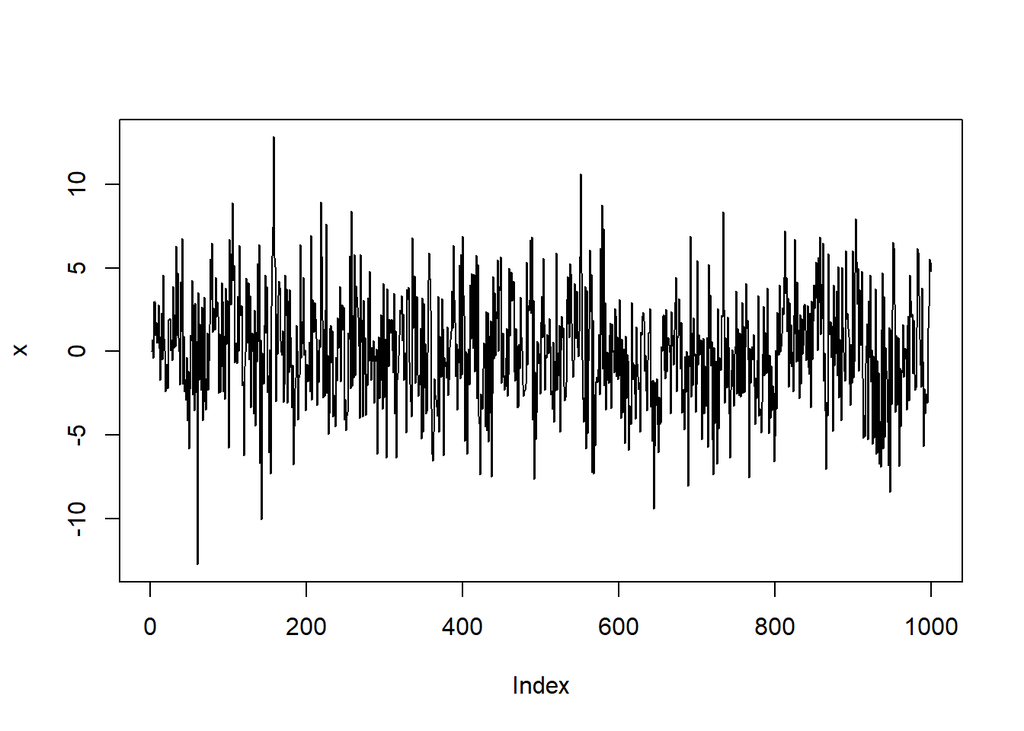

```r
n <- 1000
w <- rnorm(n)
x <- numeric(n)


for (t in 3:n)
  x[t] <- 3*w[t-2] + (1/3)*w[t-1] + w[t]

plot(x, type = 'l')
```

## 4

ii

```r
n <- 1000
w <- rnorm(n)
x <- numeric(n)


for (t in 3:n)
  x[t] <- 3*w[t-2] + (1/3)*w[t-1] + w[t]

mean(x)
```

```
## [1] 0.08979207
```

iv

```r
n <- 1e6
w <- rnorm(n)
x <- numeric(n)
x1 <- numeric(n)
x2 <- numeric(n)
x3 <- numeric(n)

for (t in 3:n)
  x[t] <- 3*w[t-2] + (1/3)*w[t-1] + w[t]

for(t in 2:n)
  x1[t] <- x[t]
cov(x,x)
```

```
## [1] 10.09888
```

```r
for(t in 2:n)
  x1[t] <- x[t-1]

cov(x,x1)
```

```
## [1] 1.346375
```

```r
for(t in 3:n)
  x2[t] <- x[t-2]

cov(x,x2)
```

```
## [1] 3.001319
```

```r
for(t in 4:n)
  x3[t] <- x[t-3]

cov(x,x3)
```

```
## [1] -0.001359239
```

# d

4. 4. Xt = Xt−1 −1/2Xt−2 +1/2Wt−1 + Wt, con X1 = 2 y X2 = 4.

## 1

El proceso estocastico es de ARMA (2,1)

## 2

Convergente (estacionario) 0.7 < 1  
## 3

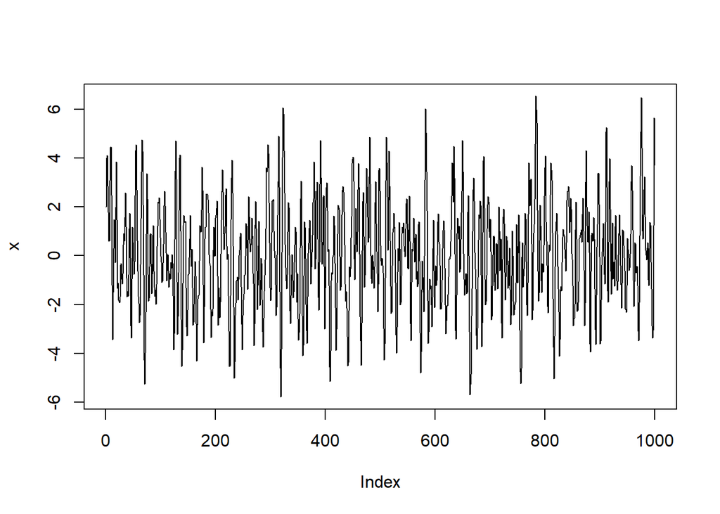

```r
n <- 1000
w <- rnorm(n)
x <- numeric(n)
x[1] <- 2
x[2] <- 4


for (t in 3:n)
  x[t] <- x[t-1] - (1/2)*x[t-2] + (1/2)*w[t-1]+ w[t]

plot(x, type = 'l')
```

# e

5. 5. Xt =3/2Xt−1 − Xt−2 +3/2Wt−3 −1/2Wt−1 + Wt, con X1 = 1 y X2 = 4.

## 1

El proceso estocastico es de ARMA (2,3)

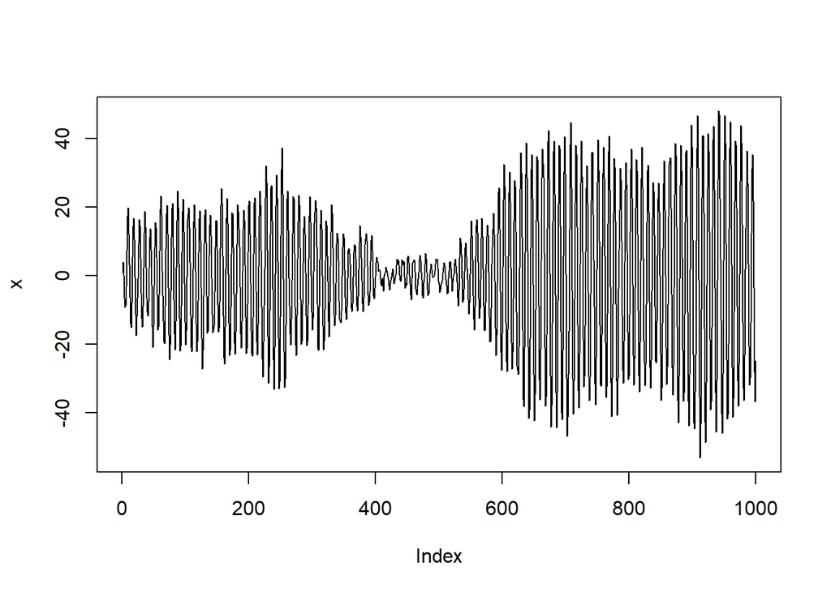

```r
n <- 1000
w <- rnorm(n)
x <- numeric(n)
x[1] <- 1
x[2] <- 4

for (t in 4:n)
  x[t] <- (3/2)*x[t-1] - x[t-2] +(3/2)*w[t-3] - (1/2)*w[t-1] + w[t]

plot(x, type = 'l')
```